# R Notebook

This notebook can be referenced in conjunction with the R Cheatsheet provided as a PDF on Canvas.

A rectangular dataset is a dataset that has an equal number of columns and rows. In R, the data structure for storing rectangular datasets is called a data frame. A data frame has column names in the first row. Let’s call this data frame values_by_state_date.

> In data science, we refer to rows in rectangular datasets as observations.

> In data science, we refer to columns in rectangular datasets as variables because they describe observations in the data. In R, columns/variables are technically vectors - a data structure for storing a series of values of the same type (e.g. character, dates, numbers).

# How did we get this data into R?

The function read.csv reads a data file stored elsewhere (on the Web or on your computer) into a data frame. In this class I will always provide you with the URL to where you can find data.

```r
#Here we read the comma separated value information at EXAMPLE.csv into the values-by_state_date. Note how we use the ‘<-‘ to assign a set of values to a variable.
values_by_state_date <- read.csv("EXAMPLE.csv")
```

```
incomplete final line found by readTableHeader on 'EXAMPLE.csv'
```

# How does R load functions?

Some functions that we apply in R are available by default. However, in this class a number of functions we will use come from packages that we will need to add on. I will always tell you what packages we need for each assignment and set of lecture exercises. You can load those packages using the library function.

```r
#Here we load the tidyverse package so that R knows that we will be using those functions
library(tidyverse)
```

# How do I apply functions to the data frame?

In this class we will apply functions to our data frame using what is called a pipe: ‘%>%’. The pipe is available through the Tidyverse package. We first call the data frame and then use the pipe to tell R that we are about to call a function like this: data_frame %>% function_name()

### What functions allow me to glimpse over the data frame?

- str() : Provides an overview of the structures of the data frame, including column names and data types
- head() : Displays the first six rows of the data frame
- dim() : Displays the number of rows in the data frame and the number of columns in the data frame
- nrow() : Displays the number of rows in the data frame
- ncol() : Displays the number of columns in the data frame
- View() : Opens the data frame as a spreadsheet in a new window
- colnames() : Displays the data frame’s column names

Examples:

```r
#Here I check the dimensions of the data frame above.
values_by_state_date %>% dim()
```

```
[1] 4 4
```

We see 4 and 4 because there are 4 rows in the data frame and 4 columns in the data frame. These are the data frame’s dimensions.

```r
#Here I check the column names of the data frame above.
values_by_state_date %>% colnames()
```

```
[1] "Date"  "State" "FIPS"  "Value"
```

This returns the column names of our dataset. We very often need to know the column names of a dataset so that we can refer to them in functions.

## How can I refer to specific columns (or variables) in R?

```r
    #Here I reference the entire last column in the data frame above. Note that because R is case-sensitive, it is important that the only capital letter below is ‘V’ in reference to the column name.
values_by_state_date$Value
```

```
[1] 3432 3546  233   NA
```

```r
values_by_state_date %>% select(Value) #We will primarily use this method in this course.
```

| Value |
| --- |
| 3432 |
| 3546 |
| 233 |
| NA |

## What functions can I apply to discrete/continuous numeric variables/columns?

### Examples of functions that can be applied to numeric columns/variables

- min() : Returns the minimum value in the column
- max() : Returns the maximum value in the column
- sum() : Returns a sum of all of the values in the column
- mean() : Returns the man of all of the values in the column
- median() : Returns the median value in the column
- sd() : Returns the standard deviation in the column
- var() : Returns the variance in the column

> An NA in a cell of a data frame indicates that there is missing data, and we need to tell R explicitly how to handle missing data when we call the mathematical operations above. To do that we place na.rm = TRUE to tell R to remove the NA when performing the calculation.

We can see the minimum value in the Values column above by calling min(). Note though that because there is one cell with a missing value, we have to tell R to remove the NA.

```r
    #Here is how I find the minimum value in Value
values_by_state_date %>%
        select(Value) %>%
        min(na.rm = TRUE)
```

```
[1] 233
```

We can see the sum of the values in the Values column by calling sum(). Again we need to tell R to remove the missing values.

```r
#Here is how I find the sum of the values in Value
values_by_state_date %>%
        select(Value) %>%
        sum(na.rm = TRUE)
```

```
[1] 7211
```

## What functions can I apply to nominal/ordinal categorical variables/columns?

### Examples of functions that can be applied to categorical columns/varialves

- unique() : Returns all of the values in the column without duplicates
- distinct() : Same as unique, but from tidyverse
- n_distinct() : Returns the number of distinct values in the column

We can see the unique values in the Date column by calling unique() or distinct(). Note how I see each date exactly once in the output. Unique removes repeating values from the column.

```r
values_by_state_date %>%
        select(Date) %>%
        unique()
```

|  | Date |
| --- | --- |
| 1 | 1/2/13 |
| 2 | 1/3/13 |

We can see the unique values in the Date and FIPS column by placing them both in select().

```r
values_by_state_date %>%
        select(Date, FIPS) %>%
        distinct()
```

| Date | FIPS |
| --- | --- |
| 1/2/13 | 1 |
| 1/3/13 | 1 |
| 1/2/13 | 6 |
| 1/3/13 | 6 |

## How do I refer to each observation/row in the data frame?

At the outset, we want to figure out which variables in the dataset can serve as identifiers for each row. This identifier or combination of identifiers should not repeat in the dataset. Otherwise we won’t know what makes one row different from another row!

There are four rows in the above dataset. What does each row refer to? We can see above that each row refers to a state and date. But remember that when we have the option to use a numeric ID, we always should. FIPS are numeric IDs for state names, so we will use that to identify each row. Note how in the last function in this page, the number of rows in which Date and FIPS are distinct is equal to the number of rows in the dataset (4).

We can check whether FIPS and Date uniquely identify each row by checking whether the number of rows where Date and FIPS are distinct is equal the number of rows in the data frame.

```r
values_by_state_date %>%
        select(Date, FIPS) %>%
        n_distinct()
```

```
[1] 4
```

Does this equal the number of rows in the dataset? How could you check?

```r
values_by_state_date %>% nrow()
```

```
[1] 4
```

## How can I count the number of times each categorical value appears in a variable?

To count the number of times each categorical value appears in a variable/column, we can use the function count(), placing the name of the column in the parentheses like this: data_frame %>% count(Variable)

```r
values_by_state_date %>%
        count(State)
```

| State | n |
| --- | --- |
| AL | 2 |
| CA | 2 |

> Note how R created a new column called n, which in this context is a shorthand for count

## Shorthand for select() %>% function() : summarize(function())

Above, we selected a variable and then performed a function on that variable, using select() %>% function(). There is a shorthand way to do this, using the function summarize() like this:

data_frame %>% summarize(FUNCTION(VARIABLE))

Sometimes it is helpful to assign the value we calculated to a new variable name. We can do this by:

data_frame %>% summarize(NEW_VARIABLE = FUNCTION(VARIABLE))

## What if I wanted to perform operations on only certain rows/observations in the data?

To perform operations on only certain rows/observations in the data, you can use the function filter(). This function filters the data to rows that meet a particular criteria. When calling this function, you will put the criteria the rows should meet in the parentheses (see below).The format for calling filter() is as follows:

data_frame %>% filter(CRITERIA)

You can test whether rows meet both of two criteria by placing an & between the criteria in the parentheses. You can test whether rows meet either criteria by placing a | between the criteria in the parentheses.

### Examples of criteria that can be tested in filter()

- filter(VARIABLE == VALUE) : Returns the row if the value in a column is equal to a provided value > Note: When filtering to a string, the string must be in “ ”.
- filter(VARIABLE > VALUE) : Returns the row if the value in a column is greater than a provided value
- filter(VARIABLE < VALUE) : Returns the row if the value in a column is less than a provided value
- filter(VARIABLE >= VALUE) : Returns the row if the value in a column is greater than or equal to a provided value
- filter(VARIABLE <= VALUE) : Returns the row if the value in a column is less than or equal to a provided value
- filter(VARIABLE != VALUE) : Returns the row if the value in a column is not equal to a provided value
- filter(VARIABLE %in% c(VALUE1, VALUE2) : Returns the row if the value in a column is in a specified list of values
- filter(is.na(VARIABLE)) : Returns the row if the value in a column is NA
- filter(!is.na(VARIABLE)) : Returns the row if the value in a column is not NA

```r
values_by_state_date %>%
        filter(State == "AL")
```

| Date | State | FIPS | Value |
| --- | --- | --- | --- |
| 1/2/13 | AL | 1 | 3432 |
| 1/3/13 | AL | 1 | 3546 |

```r
values_by_state_date %>%
        filter(Value > 1000 & Value < 3500)
```

| Date | State | FIPS | Value |
| --- | --- | --- | --- |
| 1/2/13 | AL | 1 | 3432 |

```r
values_by_state_date %>%
        filter(is.na(Value))
```

| Date | State | FIPS | Value |
| --- | --- | --- | --- |
| 1/3/13 | CA | 6 | NA |

```r
values_by_state_date %>%
        filter(Value == max(Value, na.rm = TRUE))
```

| Date | State | FIPS | Value |
| --- | --- | --- | --- |
| 1/3/13 | AL | 1 | 3546 |

```r
values_by_state_date %>%
        filter(State == "AL") %>%
        summarize(AL_sum = sum(Value, na.rm = TRUE))
```

| AL_sum |
| --- |
| 6978 |

## How can I plot data in R?

To plot data, we are going to use ggplot - a package in the Tidyverse that allows us to produce a number of visualizations from a dataset. Just like how we applied functions to data frames, we can tell R to plot data by calling our data frame and stringing the ggplot call to it with a pipe. Together this looks like this:

data_frame %>% ggplot()

However this is not enough information for R to produce a plot. We need to tell ggplot specifically what data in the data frame we would like displayed on the plot. Typically, this means telling R which variable in our dataset (or column) we would like to see on the x-axis and which variable (or column) we would like to see on the y-axis. We will tell R what to plot by referring to these variables inside of the parentheses following the call to ggplot() and more specifically inside another set of parentheses following the letters aes(). Together this looks like this:

data_frame %>% ggplot(aes(x = VARIABLE1, y = VARIABLE2)

In this case, aes() stands for aesthetics and is a way to indicate to R that we are referring to the specific variables in our dataset that we would like to see on the plot. In ggplot, aesthetics are distinct from attributes which are stylistic conventions for how the plot should be displayed (what labels it should have, what colors its bars should be, what size its fonts should be, etc.).

This is still not enough information for R to produce a plot because we haven’t indicated to R what kind of plot we want to produce! To do this, we are going to add a ‘+’ to the end of the call above and then indicate what kind of plot we would like R to produce, such as a bar plot (geom_bar()), a line plot (geom_line()), or a boxplot (geom_boxplot). We will discuss other plots later in the quarter. Together this looks like this:

data_frame %>% ggplot(aes(x = VARIABLE1, y = VARIABLE2) + geom_bar()

The code above would produce a basic plot in R. There are a number of things that we can add to this code to adjust the style of the plot. To do this we will add another ‘+’ to the end of the call above and then include new code for adjusting the plot’s style. For example, let’s say I wanted to add a title to my plot. I would add a ‘+’ to the end of the code above and then include the argument labs(title = “TITLE”) like this (labs() is short of labels):

data_frame %>% ggplot(aes(x = VARIABLE1, y = VARIABLE2) + geom_bar() + labs(title = “TITLE”)

> Why are we using ‘+’ to connect things in ggplot and not ‘%>%’? Pipes are used to string together data and functions in R. Because there is so much that can be customized with a plot, ggplot takes a number of arguments (what kind of plot it is, the plot’s title, the way the axis values get displayed, etc.) ggplot and all of the arguments associated with it are *one* function in R. So if we placed pipes between those arguments. R would be expecting a new function when in fact we are supplying it with a new ggplot argument. In ggplot, we use the + to string together arguments that are all part of the same ggplot function.

## What kinds of plots can I produce in R?

There are lots of plots that you can produce using ggplot. Rather than listing them all here, I would encourage you to view this cheatsheet: https://rstudio.com/wp-content/uploads/2015/03/ggplot2-cheatsheet.pdf

This week, we will work exclusively with bar charts. A categorical variable will be plotted on the x-axis and a numeric variable will be plotted not the y-axis. The height of the bar will summarize some statistic about the values associated with the categorical variable. This will look like this: data_frame %>% ggplot(aes(x = VARIABLE1, y = VARIABLE2) + geom_bar(stat = “summary”, fun = “sum”)

Let me break that down. We first called our data frame. Then we strung that together with the ggplot function using a pipe. Within the aesthetics we indicated that we wanted VARIABLE1 plotted on the x-axis and VARIABLE2 plotted on the y-axis. We then told ggplot that we wanted to create a bar plot by adding geom_bar(), and more specifically, we wanted to produced a bar plot that summarized the values in the y-axis variable by summing them. So what would this look like with our dataset above.

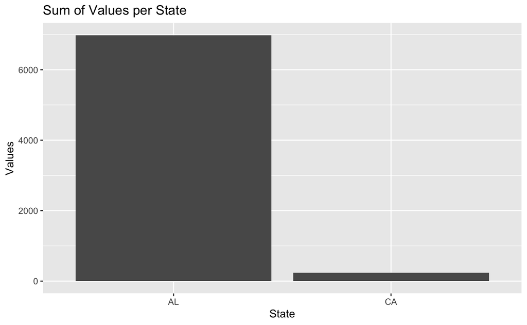

```r
values_by_state_date %>%
  ggplot(aes(x = State, y = Value)) +
  geom_bar(stat = "summary", fun = "sum") +
  labs(title = "Sum of Values per State", x = "State", y = "Values")
```

This height of the bar represents the sum of the values in AL and in CA respectively. Note that NA values will be removed in plotting by default. R will provide you with a warning indicating how many rows were removed.

> Examples of statistics that we can summarize in fun = “____” include sum, min, max, mean, and meadian. The height of the bar will indicate a summary of these values for each categorical value on the x-axis when this function is applied.

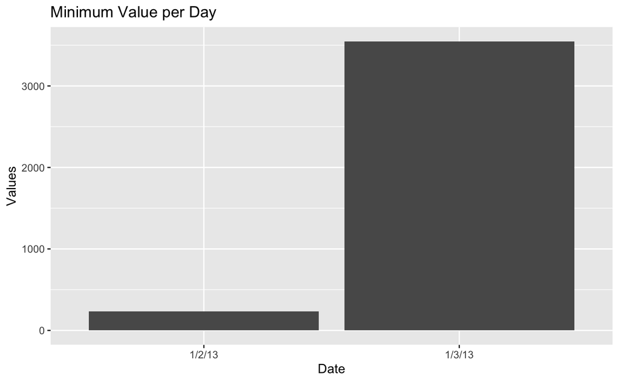

```r
values_by_state_date %>%
        ggplot(aes(x = Date, y = Value)) +
        geom_bar(stat = "summary", fun = "min") +
        labs(title = "Minimum Value per Day", x = "Date", y = "Values")
```

## What if I wanted to consider a third variable on the plot?

facet_wrap() divides a plot into separate windows, each containing the data filtered to one value in a categorical variable. We will indicate what categorical variable to divide the plots by in the parentheses following facet_wrap, following a ‘~’ like this:

data_frame %>% ggplot(aes(x = VARIABLE1, y = VARIABLE2) + geom_bar(stat = “summary”, fun = “sum”) + facet_wrap(~VARIABLE3)

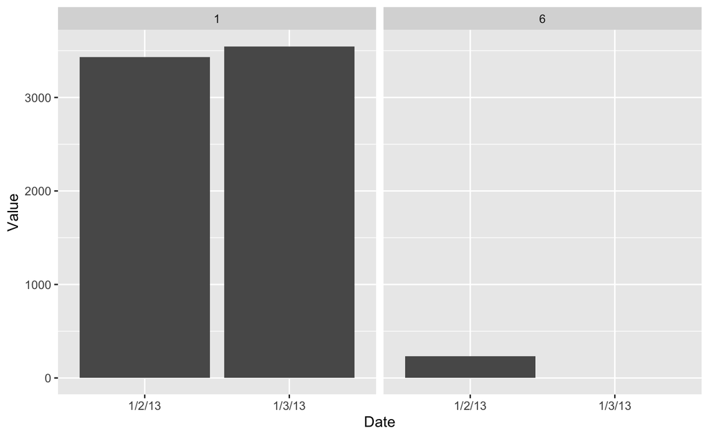

```r
values_by_state_date %>%
        ggplot(aes(x = Date, y = Value)) +
        geom_bar(stat = "summary", fun = "min") +
        facet_wrap(~as.factor(FIPS))
```

> What does as.factor do? When we imported this data into R, R saw that all of the values in FIPS were numbers. Because of this R is treating that variable as a numeric variable and assumes that we will use it in mathematical functions. But that number actually is a reference to a state so it is a categorical variable. We can use as.factor() to tell R to treat a numeric variable as a categorical variable. In these plots, we would need to do this in order to plot FIPS on the x-axis or in facet_wrap().

## What are some other ways I can show more than one variable on a bar plot?

In the bar plots we have been producing, we have been supplying a variable to plot on the x-axis and a variable to plot on the y-axis, along with a function to apply to the y-axis values. Another way we can adjust our plots to factor in more categorical data is by setting the fill property inside the aes() call. Setting fill = "___" to a categorical variable in our dataset will associate each value in that categorical variable with a particular color. The stacks of the bar plot will then be filled according to how much of the stack is associated with that variable. So for instance, let’s say we plot the sum of Value on each date, but set the fill to State.

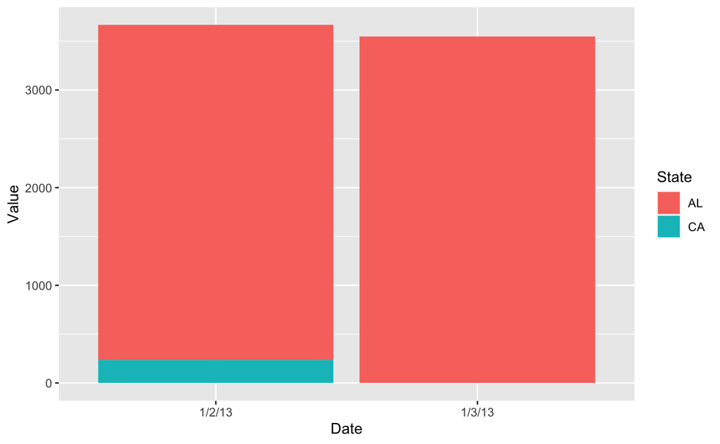

```r
values_by_state_date %>%
        ggplot(aes(x = Date, y = Value, fill = State)) +
        geom_bar(stat = "summary", fun = "sum")
```

By default, setting the fill property in a bar chart will produce a stacked bar chart like the one above. However, we can adjust this using the position attribute. To display the colored bars side-by-side, we will set the position to “dodge” like this:

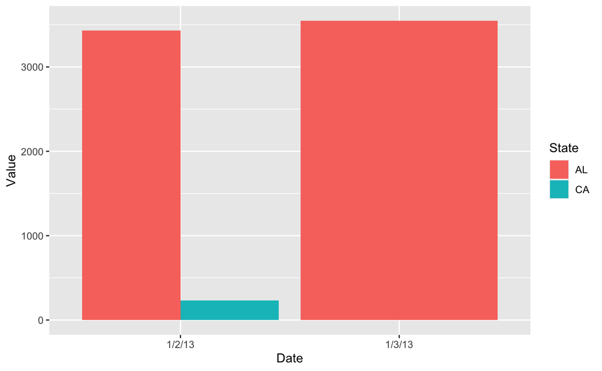

```r
values_by_state_date %>%
        ggplot(aes(x = Date, y = Value, fill = State)) +
        geom_bar(stat = "summary", fun = "sum", position = "dodge")
```

We can also display the colored bars as a percentage of the total by setting position attribute to “fill”.

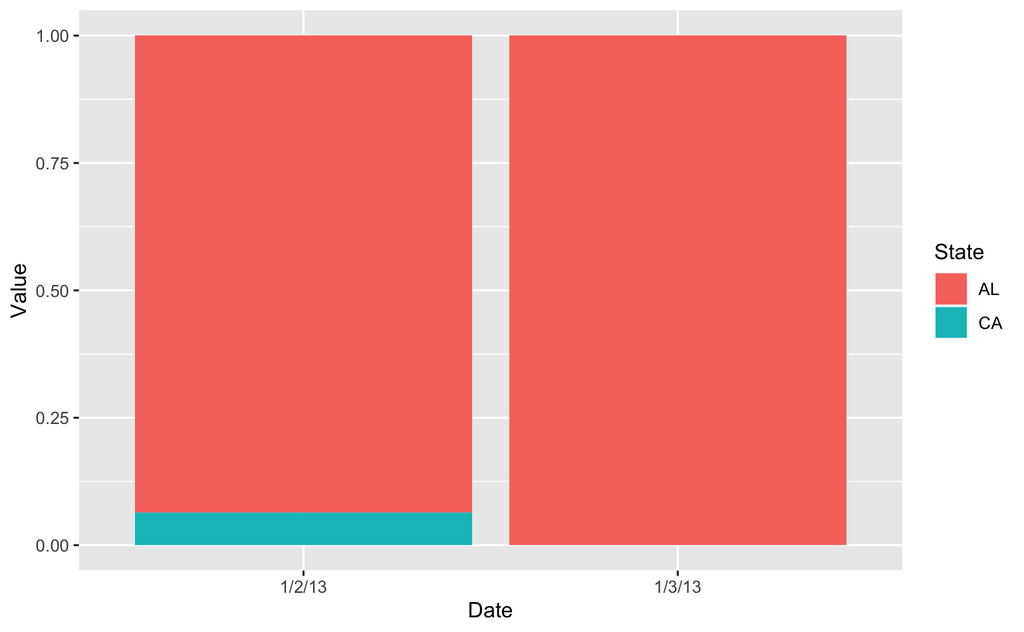

```r
values_by_state_date %>%
        ggplot(aes(x = Date, y = Value, fill = State)) +
        geom_bar(stat = "summary", fun = "sum", position = "fill")
```

## How can I summarize statistics across groups of values in R?

In R we can group observations in our datasets that share common values, using the function group_by(). group_by() takes a categorical variable in our dataset and groups all of the rows together that share the same value in that categorical variable. Let’s say we wanted to group by State. Because we have two states represented in the State variable (AL and CA), it would group the observations by these two states.

```r
values_by_state_date %>%
        group_by(State)
```

| Date | State | FIPS | Value |
| --- | --- | --- | --- |
| 1/2/13 | AL | 1 | 3432 |
| 1/3/13 | AL | 1 | 3546 |
| 1/2/13 | CA | 6 | 233 |
| 1/3/13 | CA | 6 | NA |

> Notice that on its own, group_by doesn’t show up any differently. This is because we need to apply another function to do something in each group.

On its own group_by() isn’t all that interesting. What makes it interesting is when we start to calculate certain values across these groups using the summarize function. Let’s say that I wanted to know the total Value per State. We would first need to group the rows with common states together as we did above and then calculate the sum of Value in each group.

```r
values_by_state_date %>%
        group_by(State) %>%
        summarize(Total_Value = sum(Value, na.rm = TRUE))
```

| State | Total_Value |
| --- | --- |
| AL | 6978 |
| CA | 233 |

There are a number of statistical functions that you can use in summarize (see page 3) in place of sum. Remember that summarize returns one value for each group - the result of the calculation. What if I wanted to filter to the max value in each group?

```r
values_by_state_date %>%
        group_by(State) %>%
        filter(Value == max(Value, na.rm = TRUE))
```

| Date | State | FIPS | Value |
| --- | --- | --- | --- |
| 1/3/13 | AL | 1 | 3546 |
| 1/2/13 | CA | 6 | 233 |

We see all of the columns above because we are simply subsetting our data to the row with the max of Value in each state group (i.e. in group AL and group CA). When you group_by() in an R call, the data will remain grouped, until you add %>% ungroup().

## How can I sort values?

The arrange() function allows you to sort values in R from least to greatest.

```r
values_by_state_date %>%
        group_by(State) %>%
        summarize(Total_Value = sum(Value, na.rm = TRUE)) %>%
        arrange(Total_Value)
```

| State | Total_Value |
| --- | --- |
| CA | 233 |
| AL | 6978 |

To sort the values from greatest to least you can place desc( ) inside the arrange() function like this:

```r
values_by_state_date %>%
  arrange(desc(Value))
```

| Date | State | FIPS | Value |
| --- | --- | --- | --- |
| 1/3/13 | AL | 1 | 3546 |
| 1/2/13 | AL | 1 | 3432 |
| 1/2/13 | CA | 6 | 233 |
| 1/3/13 | CA | 6 | NA |

> Note how NA values will appear at the bottom of our sorted list.

## How can I subset to the rows with the top values?

top_n() allows you to filter your data to the rows with the top values in a given variable. You supply top_n() first with the number of rows to return and the variable to find the top value in.

```r
values_by_state_date %>%
        top_n(2, Value)
```

| Date | State | FIPS | Value |
| --- | --- | --- | --- |
| 1/2/13 | AL | 1 | 3432 |
| 1/3/13 | AL | 1 | 3546 |